# How Sensitive Are Estimated Protein Networks?

Brain tissue proteomics and the consequences of analysis choices

Author

Colin Dempsey

## Research question

How much do our estimates of protein connections change when we use different statistical tests and significance levels?

During the Summer Institute in Biostatistics and Data Science (SIBDS) at Columbia, **Allison Burnett and I** worked on estimating networks of proteins under the supervision of **Dr. Daniel Malinsky**. For this class project, I wanted to take that work a step further: rather than just looking at the networks, I wanted to compare how much they change when we make different statistical choices. I focus on the number of connections, which proteins are most connected, and how many connections the networks share.

## Data and preparation

The dataset used in our summer project contains measurements of **192 proteins from 59 brain-tissue samples**. According to our original poster, the samples came from individuals with mild to moderate dementia, and the measurements were taken from the dorsolateral prefrontal cortex. The spreadsheet labels the proteins with identifiers such as `Pro1`, so I refer to them by those identifiers rather than biological names.

| Measure | Value |
| --- | --- |
| Samples | 59 |
| Proteins | 192 |
| Measurements | 11328 |
| Missing | 0 |

I excluded the sample ID column and standardized each protein variable before fitting the networks, so differences in measurement scales would not drive the analysis. Standardizing does **not** make the data normally distributed. With 59 samples and 192 protein variables, the dataset contains **11,328 protein measurements**.

## Statistical methods

### How do we estimate a protein network?

I used the **PC algorithm**, which starts with a possible connection between every pair of proteins. It then uses statistical tests to decide which connections to remove. Some tests look at two proteins directly, while others examine their relationship after accounting for additional proteins. The connections that remain form an estimated network.

The main question for this project is whether those remaining connections depend on **which statistical tests we choose**.

### What are we comparing?

I compared two testing approaches:

- **Fisher’s z-test:** uses correlations (and partial correlations when accounting for other proteins).
- **Pearson + WGCM:** uses a Pearson correlation test when no other proteins are being accounted for, and the Weighted Generalized Covariance Measure (WGCM) for conditional tests. WGCM can capture some relationships that correlation-based tests may miss.

Because the second approach uses Pearson for its first step, this is a comparison of **two testing pipelines**, not a test of WGCM by itself.

I ran each pipeline at three significance levels: **0.01, 0.05, and 0.10**, giving six networks in total. In general, a larger significance level makes it easier for a connection to remain in the estimated network. This gives us a way to see how sensitive the results are to both the test and the threshold we choose.

### What should we be careful about?

These are **estimated statistical networks**, not confirmed biological interactions. Interpreting them causally would require strong assumptions, including no important unmeasured common causes and appropriate conditional independence tests. We cannot verify those assumptions here, especially with only 59 samples and many protein variables. The PC algorithm uses its stable skeleton procedure, and the WGCM tests use simulation-based p-values; additional implementation details are retained in the project code.

```
No model warnings were recorded during these fits.
```

## How does network size change?

First, I looked at **how many connections** each method kept. A network with more connections is denser, but that does not automatically make it better. In the table below, *degree* means the number of connections a protein has, and *density* is the proportion of possible connections that remain.

| Method | Alpha | Edges | Density | Connected_proteins | Average_degree | Maximum_degree |
| --- | --- | --- | --- | --- | --- | --- |
| Fisher z | 0.01 | 94 | 0.0051 | 130 | 0.9792 | 3 |
| Fisher z | 0.05 | 127 | 0.0069 | 152 | 1.3229 | 4 |
| Fisher z | 0.10 | 154 | 0.0084 | 167 | 1.6042 | 5 |
| Pearson + WGCM | 0.01 | 1 | 0.0001 | 2 | 0.0104 | 1 |
| Pearson + WGCM | 0.05 | 17 | 0.0009 | 30 | 0.1771 | 2 |
| Pearson + WGCM | 0.10 | 63 | 0.0034 | 93 | 0.6562 | 3 |

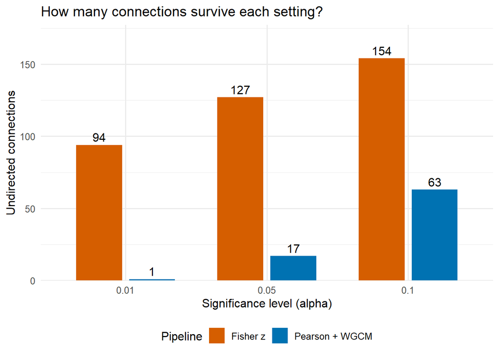

Figure 1: Retained undirected connections by testing pipeline and alpha.

Across the six settings, the number of retained connections ranges from **1 to 154**. That is a large difference for the same dataset. It tells us the estimated network depends on our analysis choices, although it does not tell us which network is closest to the truth.

## Do the same proteins remain highly connected?

Next, I wanted to know whether the **same proteins** would stand out across the six networks. The heatmap includes proteins that ranked among the five most connected in at least one setting (including ties). It shows their number of connections in every setting. A protein appearing here is not necessarily biologically important; it simply has many connections in one or more estimated networks.

In the heatmaps, **F** means Fisher z, **W** means Pearson + WGCM, and the number is the significance level.

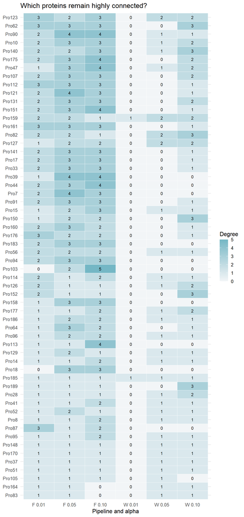

Figure 2: Degree of selected highly connected proteins across all six configurations.

The full degree and rank results for all proteins are also saved in `results/protein_degrees.csv`.

## How many connections are shared?

Finally, I compared **which specific connections** appeared in each network. I used *Jaccard similarity*: the number of connections two networks share, divided by the number found in either one. A value near **1** means the networks have very similar connections; a value near **0** means they share very few. If both networks have no connections, the value is undefined.

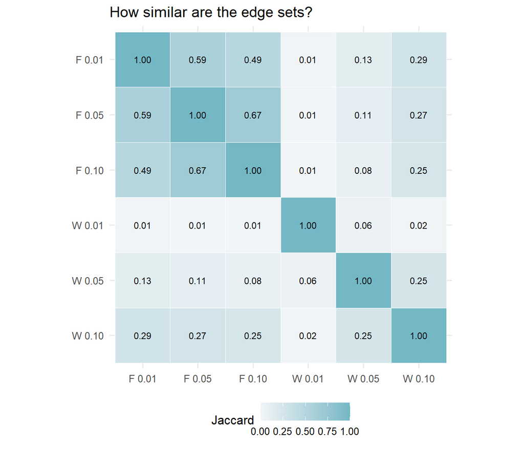

Figure 3: Jaccard similarity of undirected edge sets. F = Fisher z; W = Pearson + WGCM.

The next table holds the significance level fixed and shows how many connections are shared between the two pipelines, as well as how many appear in only one.

| Alpha | Shared_edges | Fisher_only | WGCM_pipeline_only | Jaccard |
| --- | --- | --- | --- | --- |
| 0.01 | 1 | 93 | 0 | 0.011 |
| 0.05 | 14 | 113 | 3 | 0.108 |
| 0.10 | 43 | 111 | 20 | 0.247 |

## What did I learn?

The biggest takeaway for me is that **the same dataset can produce very different-looking networks depending on the statistical approach**. Both pipelines retained more connections as the significance level increased, but Fisher z kept more connections at every level. For example, at **0.10**, Fisher z retained **154** connections compared with **63** for Pearson + WGCM. At **0.01**, the difference was even more striking: **94** versus **1**.

I also wanted to know whether the networks were finding the *same* connections, even when their sizes differed. The Jaccard comparisons suggest they often were not. At matching significance levels of **0.01, 0.05, and 0.10**, the similarities between pipelines were approximately **0.011, 0.108, and 0.247**. In other words, the two approaches frequently selected different connections.

The proteins that stood out also changed. Proteins such as **Pro123, Pro62, Pro159, and Pro82** appeared among the most connected in multiple settings, but no single protein consistently dominated all six networks.

This matters because a researcher might be tempted to focus on the proteins with the most connections in one estimated network. My results suggest that those conclusions can depend quite a bit on the analysis choices. **I can’t say which pipeline is more accurate**, because we don’t know the true underlying protein network. What I can say is that comparing methods is important before treating any one network as a definitive picture of the data.

## References and attribution

- Wang, T., et al. (2016). FastGGM: An Efficient Algorithm for the Inference of Gaussian Graphical Model in Biological Networks. *PLOS Computational Biology*, 12(2), e1004755. https://doi.org/10.1371/journal.pcbi.1004755
- Kalisch, M., et al. (2012). Causal Inference Using Graphical Models with the R Package pcalg. *Journal of Statistical Software*, 47(11), 1–26. https://doi.org/10.18637/jss.v047.i11
- Scheidegger, C., Hörrmann, J., & Bühlmann, P. (2022). The Weighted Generalised Covariance Measure. *Journal of Machine Learning Research*, 23(273), 1–68. https://www.jmlr.org/papers/v23/21-1328.html
- Software documentation: [pcalg](https://cran.r-universe.dev/pcalg/doc/manual.html) and [weightedGCM](https://cyrillsch.r-universe.dev/weightedGCM/doc/manual.html).
- Starting scripts: `weightedGCM_test_colin.R`, `weightedGCMtest_allie.R`, and `pc_automated_colin.R`, from summer work by Colin Dempsey and Allison Burnett. All six supplied summer scripts are preserved unchanged under `reference_scripts/` for provenance and are not run by this report.